# Assignment 02 Submission

Author

Sean Kim

```r
library(data.table)
library(dplyr)
library(tidyverse)
library(leaflet)

if (!file.exists("01_chs_individual"))
  download.file(
    url = "https://raw.githubusercontent.com/USCbiostats/data-science-data/master/01_chs/chs_individual.csv",
    destfile = "01_chs_individual",
    method = "libcurl",
    timeout = 1000 )


ind <- fread("01_chs_individual")



if (!file.exists("01_chs_regional"))
  download.file(
    url = "https://raw.githubusercontent.com/USCbiostats/data-science-data/master/01_chs/chs_regional.csv",
    destfile = "01_chs_regional",
    method = "libcurl",
    timeout = 1000 )
reg <- fread("01_chs_regional")
```

```r
reg[, n:= 1:.N, by = .(townname)]
reg <- reg[n == 1,][, n := NULL]

merged_data <- inner_join(ind, reg, by = "townname")
duplicate_count <- sum(duplicated(merged_data))
cat("Number of duplicate rows:", duplicate_count, "\n")
```

```
Number of duplicate rows: 0
```

```r
merged_data <- merged_data[!duplicated(merged_data), ]
```

# Data Wrangling

## Question 1 - Merge and Impute missing values

```r
#numeric missing values - replace with mean
merged_data <- merged_data %>%
  group_by(male, hispanic) %>%
  mutate(across(where(is.numeric), ~ifelse(is.na(.), mean(., na.rm = TRUE), .)))

#categorical missing values - replace with mode
merged_data <- merged_data %>%
  group_by(male, hispanic) %>%
  mutate(across(where(is.character), ~ifelse(is.na(.), Mode(.), .)))
```

## Question 2 - New variables

```r
merged_data <- merged_data %>%
  mutate(obesity_level = cut(bmi, breaks = c(-Inf, 14, 22, 24, Inf), labels = c("Underweight", "Normal", "Overweight", "Obese")))


summary_byObLvl <- merged_data %>%
  group_by(obesity_level) %>%
  summarise(
    min_BMI = min(bmi, na.rm = TRUE),
    max_BMI = max(bmi, na.rm = TRUE),
    total_observations = n()
  )
summary_byObLvl
```

```
# A tibble: 4 × 4
  obesity_level min_BMI max_BMI total_observations
  <fct>           <dbl>   <dbl>              <int>
1 Underweight      11.3    14.0                 35
2 Normal           14.0    22.0                975
3 Overweight       22.0    24.0                 87
4 Obese            24.0    41.3                103
```

## Question 3 - smoke gas exposure

```r
merged_data <- merged_data %>%
  mutate(smoke_gas_exposure = case_when(
    smoke == 0 & gasstove == 0 ~ "No Exposure",
    smoke > 0 & gasstove == 0 ~ "Smoke Exposure",
    smoke == 0 & gasstove > 0 ~ "Gas Exposure",
    smoke > 0 & gasstove > 0 ~ "Both"
  ))

head(merged_data)
```

```
# A tibble: 6 × 51
# Groups:   male, hispanic [4]
    sid townname   male race  hispanic agepft height weight   bmi asthma
  <int> <chr>     <int> <chr>    <int>  <dbl>  <dbl>  <dbl> <dbl>  <dbl>
1     1 Lancaster     1 W            0  10.2    123    54    16.2      0
2     2 Lancaster     1 W            0  10.5    145    77    16.6      0
3     6 Lancaster     0 B            0  10.1    145   143    30.9      0
4     7 Lancaster     0 O            0  10.7    156    72    13.4      0
5     8 Lancaster     0 W            1   9.78   132    61    15.9      0
6    10 Lancaster     1 O            1   9.97   139.   82.8  19.4      0
# ℹ 41 more variables: active_asthma <int>, father_asthma <dbl>,
#   mother_asthma <dbl>, wheeze <dbl>, hayfever <dbl>, allergy <dbl>,
#   educ_parent <dbl>, smoke <dbl>, pets <int>, gasstove <dbl>, fev <dbl>,
#   fvc <dbl>, mmef <dbl>, pm25_mass <dbl>, pm25_so4 <dbl>, pm25_no3 <dbl>,
#   pm25_nh4 <dbl>, pm25_oc <dbl>, pm25_ec <dbl>, pm25_om <dbl>, pm10_oc <dbl>,
#   pm10_ec <dbl>, pm10_tc <dbl>, formic <dbl>, acetic <dbl>, hcl <dbl>,
#   hno3 <dbl>, o3_max <dbl>, o3106 <dbl>, o3_24 <dbl>, no2 <dbl>, …
```

## Question 4 - Summary tables of FEV1

```r
summary_table_town <- merged_data %>%
  group_by(townname) %>%
  summarise(
    avg_FEV = mean(fev, na.rm = TRUE),
    sd_FEV = sd(fev, na.rm = TRUE)
  )

summary_table_sex <- merged_data %>%
  group_by(male) %>%
  summarise(
    avg_FEV = mean(fev, na.rm = TRUE),
    sd_FEV = sd(fev, na.rm = TRUE)
  )

summary_table_obesity <- merged_data %>%
  group_by(obesity_level) %>%
  summarise(
    avg_FEV = mean(fev, na.rm = TRUE),
    sd_FEV = sd(fev, na.rm = TRUE)
  )

summary_table_exposure <- merged_data %>%
  group_by(smoke_gas_exposure) %>%
  summarise(
    avg_FEV = mean(fev, na.rm = TRUE),
    sd_FEV = sd(fev, na.rm = TRUE)
  )

print("Summary Table by Town:")
```

```
[1] "Summary Table by Town:"
```

```r
print(summary_table_town)
```

```
# A tibble: 12 × 3
   townname      avg_FEV sd_FEV
   <chr>           <dbl>  <dbl>
 1 Alpine          2087.   291.
 2 Atascadero      2076.   324.
 3 Lake Elsinore   2039.   304.
 4 Lake Gregory    2085.   320.
 5 Lancaster       2003.   317.
 6 Lompoc          2034.   351.
 7 Long Beach      1986.   319.
 8 Mira Loma       1985.   325.
 9 Riverside       1990.   278.
10 San Dimas       2027.   319.
11 Santa Maria     2026.   312.
12 Upland          2024.   343.
```

```r
print("\nSummary Table by Sex:")
```

```
[1] "\nSummary Table by Sex:"
```

```r
print(summary_table_sex)
```

```
# A tibble: 2 × 3
   male avg_FEV sd_FEV
  <int>   <dbl>  <dbl>
1     0   1959.   312.
2     1   2104.   308.
```

```r
print("\nSummary Table by Obesity Level:")
```

```
[1] "\nSummary Table by Obesity Level:"
```

```r
print(summary_table_obesity)
```

```
# A tibble: 4 × 3
  obesity_level avg_FEV sd_FEV
  <fct>           <dbl>  <dbl>
1 Underweight     1698.   303.
2 Normal          2000.   295.
3 Overweight      2224.   317.
4 Obese           2266.   325.
```

```r
print("\nSummary Table by Smoke Gas Exposure:")
```

```
[1] "\nSummary Table by Smoke Gas Exposure:"
```

```r
print(summary_table_exposure)
```

```
# A tibble: 4 × 3
  smoke_gas_exposure avg_FEV sd_FEV
  <chr>                <dbl>  <dbl>
1 Both                 2021.   307.
2 Gas Exposure         2024.   319.
3 No Exposure          2055.   330.
4 Smoke Exposure       2063.   290.
```

# EDA

## Question 1: BMI vs FEV?

```r
summary(merged_data$bmi)
```

```
   Min. 1st Qu.  Median    Mean 3rd Qu.    Max.
  11.30   15.96   17.81   18.50   19.99   41.27
```

```r
summary(merged_data$fev)
```

```
   Min. 1st Qu.  Median    Mean 3rd Qu.    Max.
  984.8  1827.6  2016.4  2030.1  2223.6  3323.7
```

```r
cor(merged_data$bmi, merged_data$fev, use = "complete.obs")
```

```
[1] 0.357112
```

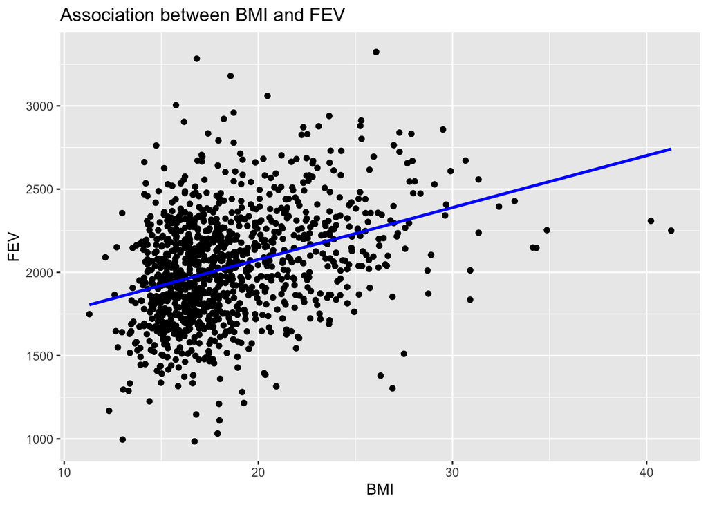

```r
ggplot(merged_data, aes(x = bmi, y = fev)) +
  geom_point() +
  geom_smooth(method = "lm", se = FALSE, color = "blue") +
  labs(title = "Association between BMI and FEV",
       x = "BMI",
       y = "FEV")
```

## Question 2: smoke/gas exposure vs FEV?

```r
summary(merged_data$smoke_gas_exposure)
```

```
   Length     Class      Mode
     1200 character character
```

```r
summary(merged_data$fev)
```

```
   Min. 1st Qu.  Median    Mean 3rd Qu.    Max.
  984.8  1827.6  2016.4  2030.1  2223.6  3323.7
```

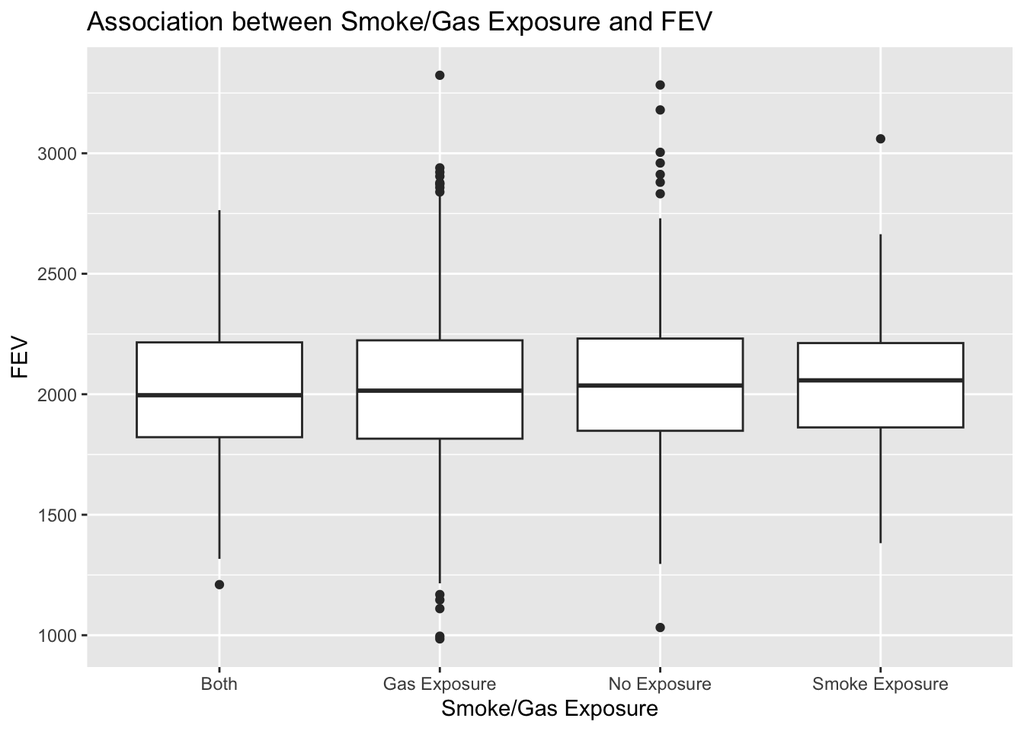

```r
ggplot(merged_data, aes(x = smoke_gas_exposure, y = fev)) +
  geom_boxplot() +
  labs(title = "Association between Smoke/Gas Exposure and FEV",
       x = "Smoke/Gas Exposure",
       y = "FEV")
```

Exposure to both smoke and gas seems to be associated with a lower FEV compared to just one or the other. There is significant variation between groups, evidenced by overlap in the box plots.

## Question 3: PM2.5 vs FEV?

```r
summary(merged_data$pm2_5_fr)
```

```
   Min. 1st Qu.  Median    Mean 3rd Qu.    Max.
   9.01   13.47   19.94   19.80   25.93   31.55
```

```r
summary(merged_data$fev)
```

```
   Min. 1st Qu.  Median    Mean 3rd Qu.    Max.
  984.8  1827.6  2016.4  2030.1  2223.6  3323.7
```

```r
cor(merged_data$pm2_5_fr, merged_data$fev, use = "complete.obs")
```

```
[1] -0.08133149
```

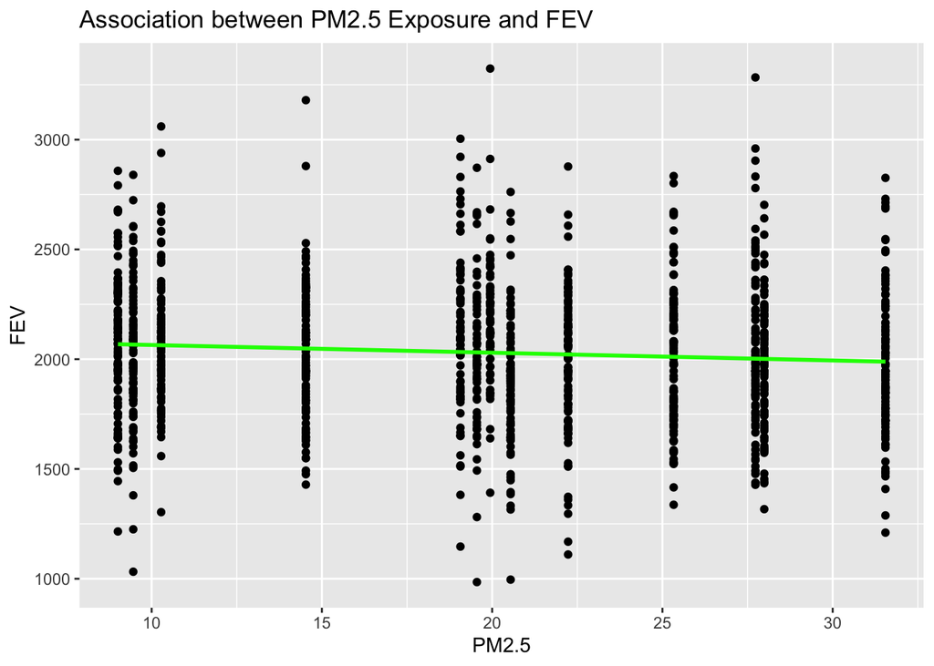

```r
ggplot(merged_data, aes(x = pm2_5_fr, y = fev)) +
  geom_point() +
  geom_smooth(method = "lm", se = FALSE, color = "green") +
  labs(title = "Association between PM2.5 Exposure and FEV",
       x = "PM2.5",
       y = "FEV")
```

Slight negative association between PM2.5 concentration exposure and FEV (cor = -0.08). This is reasonable considering PM2.5 is a fine particle that would likely damage the lungs. Increased exposure to PM2.5 should lead to a lower FEV.

# Data Visualization

1. Facet plot showing scatterplots with regression lines of BMI vs FEV by “townname”.

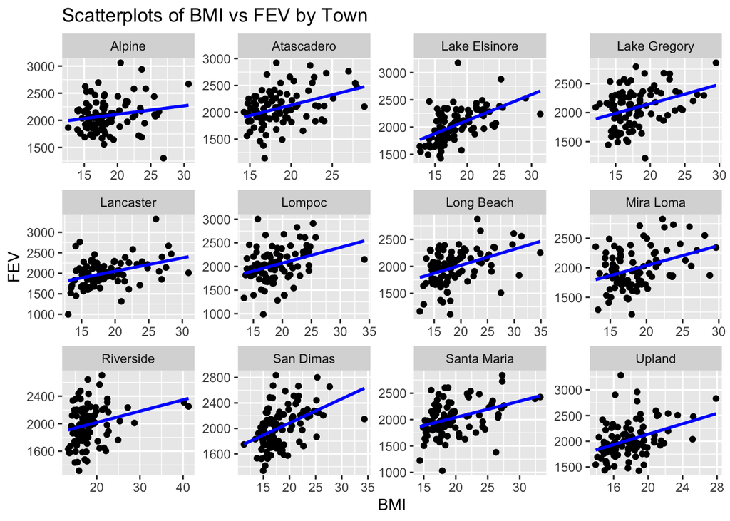

   ```r
   ggplot(merged_data, aes(x = bmi, y = fev))+
            geom_point()+
            geom_smooth(method = "lm", se = FALSE, color = "blue") +
            facet_wrap(~townname, scales = "free")+
            labs(title = "Scatterplots of BMI vs FEV by Town",
          x = "BMI",
          y = "FEV")
   ```

2. Stacked histograms of FEV by BMI category and FEV by smoke/gas exposure. Use different color schemes than the ggplot default.

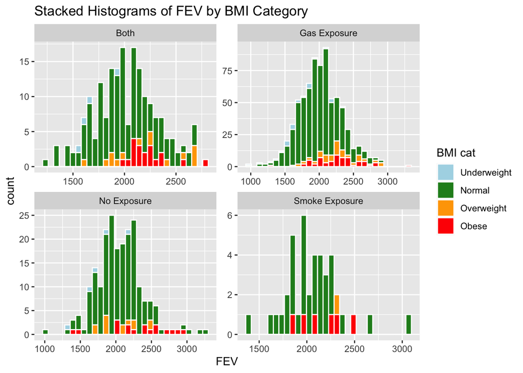

   ```r
   custom_colors <- c("Underweight" = "lightblue", "Normal" = "forestgreen", "Overweight" = "orange", "Obese" = "red")

   ggplot(merged_data, aes(x = fev, fill = obesity_level)) +
     geom_histogram(position = "stack", bins = 30, color = "white") +
     scale_fill_manual(values = custom_colors) +
     labs(title = "Stacked Histograms of FEV by BMI Category",
          x = "FEV",
          fill = "BMI cat") +
     facet_wrap(~smoke_gas_exposure, scales = "free")
   ```

3. Barchart of BMI by smoke/gas exposure.

   ```r
   bmi_smokegas_data <- merged_data %>%
     group_by(smoke_gas_exposure) %>%
     summarize(mean_bmi = mean(bmi))
   bmi_smokegas_data
   ```

   ```
   # A tibble: 4 × 2
     smoke_gas_exposure mean_bmi
     <chr>                 <dbl>
   1 Both                   19.0
   2 Gas Exposure           18.4
   3 No Exposure            18.2
   4 Smoke Exposure         19.2
   ```

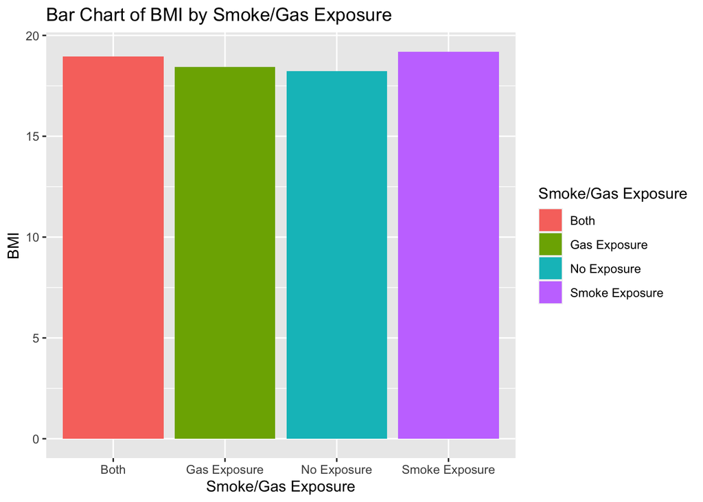

   ```r
   ggplot(bmi_smokegas_data, aes(x = smoke_gas_exposure, y = mean_bmi, fill = smoke_gas_exposure)) +
     geom_bar(stat = "identity") +
     labs(title = "Bar Chart of BMI by Smoke/Gas Exposure",
          x = "Smoke/Gas Exposure",
          y = "BMI",
          fill = "Smoke/Gas Exposure")
   ```

4. Statistical summary graphs of FEV by BMI and FEV by smoke/gas exposure category.

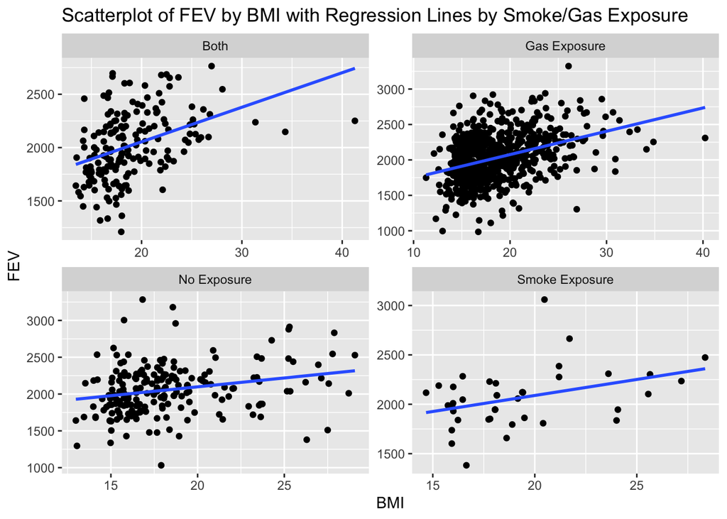

   ```r
   ggplot(merged_data, aes(x = bmi, y = fev)) +
     geom_point()+
     geom_smooth(method = "lm", se = FALSE)+
     labs(title = "Scatterplot of FEV by BMI with Regression Lines by Smoke/Gas Exposure",
          x = "BMI",
          y = "FEV",
          color = "Smoke/Gas Exposure") +
     facet_wrap(~smoke_gas_exposure, scales = "free")
   ```

   ```r
   leaflet(merged_data) %>%
     addTiles() %>%
     addCircles(lng = ~lon, lat = ~lat, weight = 5, radius = ~pm2_5_fr * 10, popup = ~paste(townname, "PM2.5: ", pm2_5_fr))
   ```

[interactive chart not shown]

6. Choose a visualization to examine whether PM2.5 mass is associated with FEV.

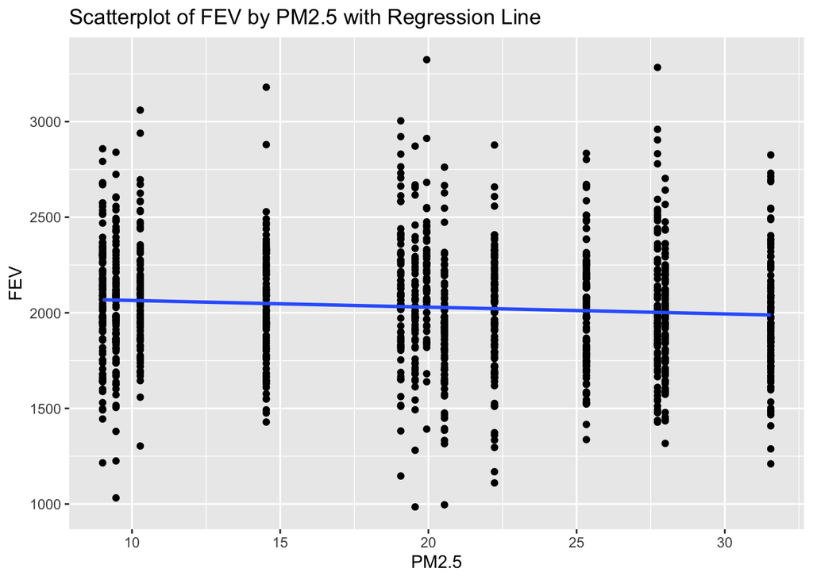

   ```r
   ggplot(merged_data, aes(x = pm2_5_fr, y = fev))+
     geom_point()+
     geom_smooth(method = "lm", se = FALSE)+
     labs(title = "Scatterplot of FEV by PM2.5 with Regression Line",
          x = "PM2.5",
          y = "FEV")
   ```

```r
merged_data %>%
  mutate(pm2_5_fr = round(pm2_5_fr, 4))
```

```
# A tibble: 1,200 × 51
# Groups:   male, hispanic [4]
     sid townname   male race  hispanic agepft height weight   bmi asthma
   <int> <chr>     <int> <chr>    <int>  <dbl>  <dbl>  <dbl> <dbl>  <dbl>
 1     1 Lancaster     1 W            0  10.2    123    54    16.2      0
 2     2 Lancaster     1 W            0  10.5    145    77    16.6      0
 3     6 Lancaster     0 B            0  10.1    145   143    30.9      0
 4     7 Lancaster     0 O            0  10.7    156    72    13.4      0
 5     8 Lancaster     0 W            1   9.78   132    61    15.9      0
 6    10 Lancaster     1 O            1   9.97   139.   82.8  19.4      0
 7    13 Lancaster     1 O            1  10.2    140    79    18.3      0
 8    16 Lancaster     0 W            0  10.4    141    74    16.9      1
 9    19 Lancaster     0 W            0   9.85   139.   77.4  18.1      0
10    21 Lancaster     0 W            1   9.94   126    59    16.9      0
# ℹ 1,190 more rows
# ℹ 41 more variables: active_asthma <int>, father_asthma <dbl>,
#   mother_asthma <dbl>, wheeze <dbl>, hayfever <dbl>, allergy <dbl>,
#   educ_parent <dbl>, smoke <dbl>, pets <int>, gasstove <dbl>, fev <dbl>,
#   fvc <dbl>, mmef <dbl>, pm25_mass <dbl>, pm25_so4 <dbl>, pm25_no3 <dbl>,
#   pm25_nh4 <dbl>, pm25_oc <dbl>, pm25_ec <dbl>, pm25_om <dbl>, pm10_oc <dbl>,
#   pm10_ec <dbl>, pm10_tc <dbl>, formic <dbl>, acetic <dbl>, hcl <dbl>, …
```

```r
merged_data$pm2_5_fr <- as.factor(merged_data$pm2_5_fr)
anova_result <- aov(fev ~ pm2_5_fr, data = merged_data)
summary(anova_result)
```

```
              Df    Sum Sq Mean Sq F value   Pr(>F)
pm2_5_fr      12   4462995  371916    3.78 1.16e-05 ***
Residuals   1187 116781500   98384
---
Signif. codes:  0 '***' 0.001 '**' 0.01 '*' 0.05 '.' 0.1 ' ' 1
```

```r
tukey_results <- TukeyHSD(anova_result)
summary(tukey_results)
```

```
         Length Class  Mode
pm2_5_fr 312    -none- numeric
```

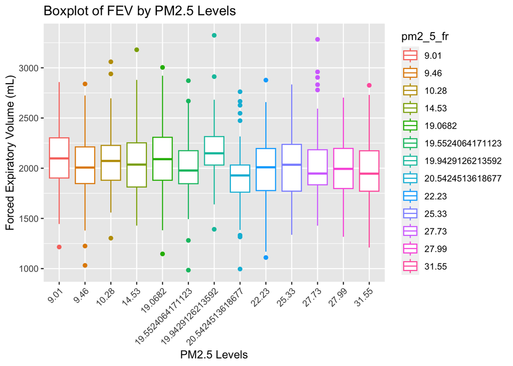

```r
ggplot(merged_data, aes(x = pm2_5_fr, y = fev, color = pm2_5_fr)) +
  geom_boxplot() +
  labs(title = "Boxplot of FEV by PM2.5 Levels",
       x = "PM2.5 Levels",
       y = "Forced Expiratory Volume (mL)")+
  theme(axis.text.x = element_text(angle = 45, hjust = 1))
```

```r
FEV_PM2_5_groups <- merged_data %>%
  group_by(pm2_5_fr) %>%
  summarize(mean_fev = mean(fev))
FEV_PM2_5_groups
```

```
# A tibble: 13 × 2
   pm2_5_fr         mean_fev
   <fct>               <dbl>
 1 9.01                2085.
 2 9.46                2026.
 3 10.28               2087.
 4 14.53               2039.
 5 19.0682             2116.
 6 19.5524064171123    2010.
 7 19.9429126213592    2179.
 8 20.5424513618677    1912.
 9 22.23               1986.
10 25.33               2027.
11 27.73               2024.
12 27.99               1990.
13 31.55               1985.
```

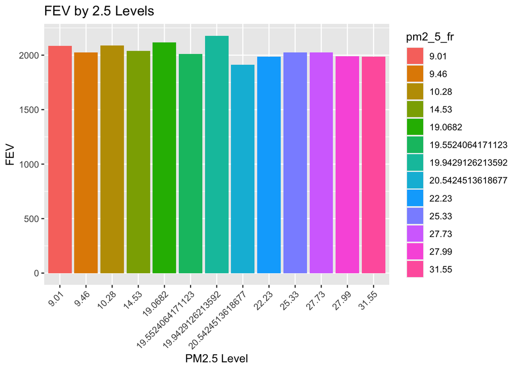

```r
ggplot(FEV_PM2_5_groups, aes(x = pm2_5_fr, y = mean_fev, fill = pm2_5_fr)) +
  geom_bar(stat = "identity") +
  labs(title = "FEV by 2.5 Levels",
       x = "PM2.5 Level",
       y = "FEV")+
   theme(axis.text.x = element_text(angle = 45, hjust = 1))
```